# Meta-regression weighted gamlss models

Anuschka Peelen

2023-05-18

In this script, I perform meta-analyses for the models and test the hypotheses

```r
rm(list=ls())
library(meta)
library(metafor)
library(here)
library(dplyr)
library(kableExtra)
here()
set.seed(1)
here::i_am("scripts/analysis/meta_analysis_gamlss_weigh.Rmd")
```

## Forest plots

```r
# With the final data
load(here("./data/meta_analysis", "total_reg_results_gam_w_new.RData"))

# Step 1. Estimate the empty model without moderators to make the forest plots.
model_step_1_att <- rma(yi = mu_time,
              sei = mu_time_sd,
              data = total_reg_results,
              method = "REML",
              test = "knha")

model_step_1_att

# I want to assign different colors to the different types of dependent variables, so that one can easily distinguish
# the types of attitudes by colors in the forest plot
total_reg_results$colour <- NA
total_reg_results$colour[total_reg_results$attitude_cat=="cognitive"] <- "#2980B9" # blue
total_reg_results$colour[total_reg_results$attitude_cat=="affective"] <- "#CC5279" # pink
total_reg_results$colour[total_reg_results$attitude_cat=="behavioral"] <- "#B0CC52" # green

colour.palette <- as.vector(total_reg_results$colour)

# Make a forest plot (has to be done outside codechunk, otherwise it doesn't save)
# I want to add the pooled effect sizes from the affective, behavioral and cognitive seperately to this forest plot.
# First run those models
affective <- subset(total_reg_results, attitude_cat == "affective")

aff_model <- rma(yi = mu_time,
              sei = mu_time_sd,
              data = affective,
              method = "REML",
              test = "knha")

behavioral <- subset(total_reg_results, attitude_cat == "behavioral")

beh_model <- rma(yi = mu_time,
              sei = mu_time_sd,
              data = behavioral,
              method = "REML",
              test = "knha")

cognitive <- subset(total_reg_results, attitude_cat == "cognitive")

cog_model <- rma(yi = mu_time,
              sei = mu_time_sd,
              data = cognitive,
              method = "REML",
              test = "knha")
```

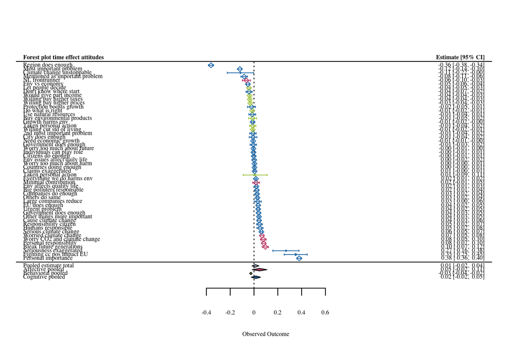

```r
# Now plot the model with the 4 pooled effects
# The argument order = "yi" puts the effects in order from negative to positive
# If I don't use the brackets, Rmarkdown doesn't recognize the plot
# I would like to change the names of the variables so that they are a bit more descriptive and look better
total_reg_results$dep_var_name[total_reg_results$dep_var == "dodiff"] <- "Do things differently"
total_reg_results$dep_var_name[total_reg_results$dep_var == "frontrunner"] <- "NL frontrunner"
total_reg_results$dep_var_name[total_reg_results$dep_var == "min_contr"] <- "Minimal contribution"
total_reg_results$dep_var_name[total_reg_results$dep_var == "people_decide"] <- "Let people decide"
total_reg_results$dep_var_name[total_reg_results$dep_var == "econprotect"] <- "Need economic growth"
total_reg_results$dep_var_name[total_reg_results$dep_var == "growharm"] <- "Growth harms env"
total_reg_results$dep_var_name[total_reg_results$dep_var == "bus_decide"] <- "Let business decide"
total_reg_results$dep_var_name[total_reg_results$dep_var == "othersame"] <- "Others do same"
total_reg_results$dep_var_name[total_reg_results$dep_var == "resp_citiz"] <- "Responsibility citizen"
total_reg_results$dep_var_name[total_reg_results$dep_var == "dk_start"] <- "Don't know where start"
total_reg_results$dep_var_name[total_reg_results$dep_var == "buss_help"] <- "Large companies reduce"
total_reg_results$dep_var_name[total_reg_results$dep_var == "envp_eg"] <- "Protection boosts growth"
total_reg_results$dep_var_name[total_reg_results$dep_var == "effr_eg"] <- "Use natural resources"
total_reg_results$dep_var_name[total_reg_results$dep_var == "env_quallife"] <- "Env affects quality life"
total_reg_results$dep_var_name[total_reg_results$dep_var == "cc_unstop"] <- "Climate change unstoppable"
total_reg_results$dep_var_name[total_reg_results$dep_var == "cc_poseu"] <- "Fighting cc pos impact EU"
total_reg_results$dep_var_name[total_reg_results$dep_var == "big_pol"] <- "Big polluters responsible"
total_reg_results$dep_var_name[total_reg_results$dep_var == "pers_resp"] <- "Personal responsiblity"
total_reg_results$dep_var_name[total_reg_results$dep_var == "worry"] <- "Worried climate change"
total_reg_results$dep_var_name[total_reg_results$dep_var == "worried"] <- "Worry CO2 and climate change"
total_reg_results$dep_var_name[total_reg_results$dep_var == "worry_future"] <- "Bleak future generations"
total_reg_results$dep_var_name[total_reg_results$dep_var == "willing_price"] <- "Willing pay higher prices"
total_reg_results$dep_var_name[total_reg_results$dep_var == "willing_tax"] <- "Willing pay higher taxes"
total_reg_results$dep_var_name[total_reg_results$dep_var == "willing_living"] <- "Willing cut std of living"
total_reg_results$dep_var_name[total_reg_results$dep_var == "do_right"] <- "Do what is right"
total_reg_results$dep_var_name[total_reg_results$dep_var == "climate5"] <- "Would give part income"
total_reg_results$dep_var_name[total_reg_results$dep_var == "prsaction"] <- "Taken personal action"
total_reg_results$dep_var_name[total_reg_results$dep_var == "cc_prsact"] <- "Taken personal action"
total_reg_results$dep_var_name[total_reg_results$dep_var == "buyprod"] <- "Buy environmental products"
total_reg_results$dep_var_name[total_reg_results$dep_var == "worry_issp"] <- "Worry too much about future"
total_reg_results$dep_var_name[total_reg_results$dep_var == "lifeharm"] <- "Everything we do harms env"
total_reg_results$dep_var_name[total_reg_results$dep_var == "progharm"] <- "Worry too much about harm"
total_reg_results$dep_var_name[total_reg_results$dep_var == "moreimp"] <- "Other things more important"
total_reg_results$dep_var_name[total_reg_results$dep_var == "exag"] <- "Claims exaggerated"
total_reg_results$dep_var_name[total_reg_results$dep_var == "country_effort"] <- "Countries doing enough"
total_reg_results$dep_var_name[total_reg_results$dep_var == "cause"] <- "Cause climate change"
total_reg_results$dep_var_name[total_reg_results$dep_var == "human_resp"] <- "Humans responsible"
total_reg_results$dep_var_name[total_reg_results$dep_var == "env_ec_stat"] <- "Env vs economy"
total_reg_results$dep_var_name[total_reg_results$dep_var == "env_prsimp"] <- "Urgent problem"
total_reg_results$dep_var_name[total_reg_results$dep_var == "cchange"] <- "Most important problem"
total_reg_results$dep_var_name[total_reg_results$dep_var == "cchange2"] <- "2nd most important problem"
total_reg_results$dep_var_name[total_reg_results$dep_var == "cchangetot"] <- "Mentioned as important problem"
total_reg_results$dep_var_name[total_reg_results$dep_var == "ccpercept"] <- "Serious climate change"
total_reg_results$dep_var_name[total_reg_results$dep_var == "doprot_comp"] <- "Companies do enough"
total_reg_results$dep_var_name[total_reg_results$dep_var == "doprot_citiz"] <- "Citizens do enough"
total_reg_results$dep_var_name[total_reg_results$dep_var == "doprot_region"] <- "Region does enough"
total_reg_results$dep_var_name[total_reg_results$dep_var == "do_gov"] <- "Government does enough"
total_reg_results$dep_var_name[total_reg_results$dep_var == "doprot_natgov"] <- "Government does enough"
total_reg_results$dep_var_name[total_reg_results$dep_var == "doprot_eu"] <- "EU does enough"
total_reg_results$dep_var_name[total_reg_results$dep_var == "doprot_city"] <- "City does enough"
total_reg_results$dep_var_name[total_reg_results$dep_var == "cc_exag"] <- "Seriousness exaggerated"
total_reg_results$dep_var_name[total_reg_results$dep_var == "role_ind"] <- "Individuals can play role"
total_reg_results$dep_var_name[total_reg_results$dep_var == "eff_daily"] <- "Env issues affect daily life"
total_reg_results$dep_var_name[total_reg_results$dep_var == "pers_imp"] <- "Personal importance"

{png <- forest(model_step_1_att, colout = colour.palette, col = "#ACBFD6", annotate = TRUE, header = "Forest plot time effect attitudes", slab = total_reg_results$dep_var_name, pch = 23,fonts = "Times", ylim = c(-4.5, 55), cex = 0.5, mlab = "Pooled estimate total", order = "yi", ilab = mean_year, ilab.xpos = -4, xlim = c(-2, 2))

addpoly.rma(aff_model, row = -2, mlab = "Affective pooled", col = "#CC5279")
addpoly.rma(beh_model, row = -3, mlab = "Behavioral pooled", col = "#B0CC52")
addpoly.rma(cog_model, row = -4, mlab = "Cognitive pooled", col = "#2980B9")
}
```

```r
# The plot can only be saved outside of the codechunk, hence the code underneath
```

Mean attitudes png(file = “/Users/anuschka/Documents/climatechange/climatechange/output/forestplot_neg_to_pos_weight.png”, width = 2800, height = 2400, res = 300)

{png <- forest(model_step_1_att, colout = colour.palette, col = “#ACBFD6”, annotate = TRUE, header = “Forest plot time effect attitudes”, slab = total_reg_results$dep_var_name, pch = 23,fonts = “Times”, ylim = c(-4.5, 55), cex = 0.5, mlab = “Pooled estimate total”, order = “yi”)

addpoly.rma(aff_model, row = -2, mlab = “Affective pooled”, col = “#CC5279”) addpoly.rma(beh_model, row = -3, mlab = “Behavioral pooled”, col = “#B0CC52”) addpoly.rma(cog_model, row = -4, mlab = “Cognitive pooled”, col = “#2980B9”) }

dev.off()

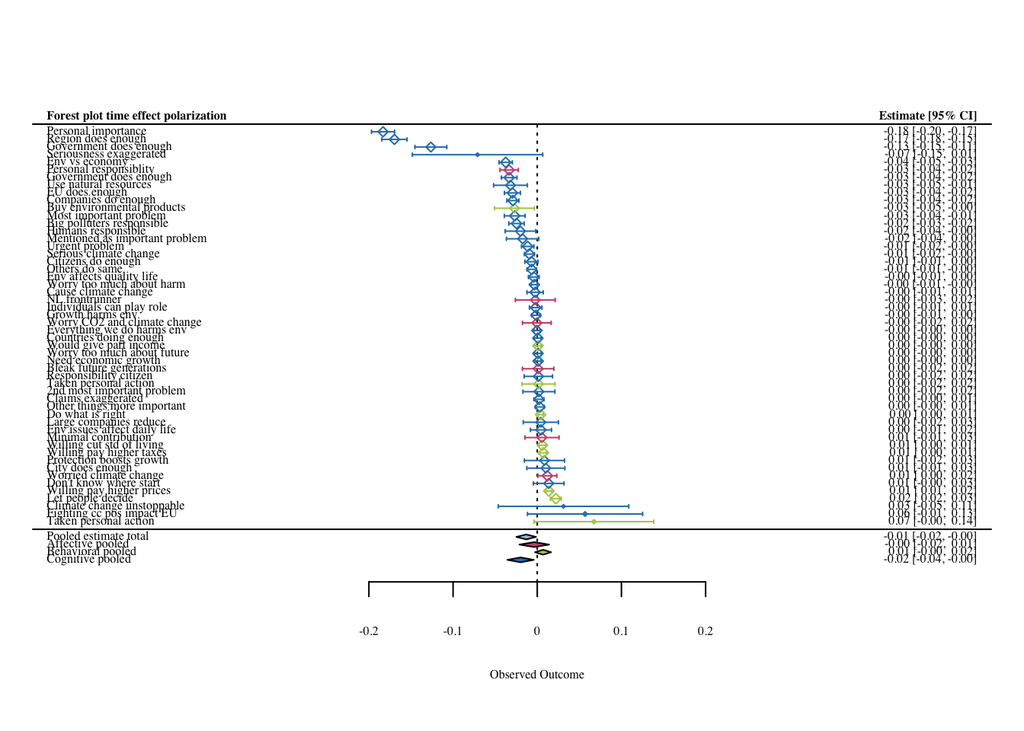

```r
# Repeat step 1, but then for the polarization (variance)
model_step_1_var <- rma(yi = sig_time,
              sei = sig_time_sd,
              data = total_reg_results,
              method = "REML",
              test = "knha")

model_step_1_var

aff_model_var <- rma(yi = sig_time,
              sei = sig_time_sd,
              data = affective,
              method = "REML",
              test = "knha")

beh_model_var <- rma(yi = sig_time,
              sei = sig_time_sd,
              data = behavioral,
              method = "REML",
              test = "knha")

cog_model_var <- rma(yi = sig_time,
              sei = sig_time_sd,
              data = cognitive,
              method = "REML",
              test = "knha")

{png <- forest(model_step_1_var, colout = colour.palette, col = "#ACBFD6", annotate = TRUE, header = "Forest plot time effect polarization", slab = total_reg_results$dep_var_name, pch = 23,fonts = "Times", cex = 0.5, ylim = c(-4.5, 55), mlab = "Pooled estimate total", order = "yi")

addpoly.rma(aff_model_var, row = -2, mlab = "Affective pooled", col = "#CC5279")
addpoly.rma(beh_model_var, row = -3, mlab = "Behavioral pooled", col = "#B0CC52")
addpoly.rma(cog_model_var, row = -4, mlab = "Cognitive pooled", col = "#2980B9")}
```

```r
# And also make the forest plot for the variance
```

Polarization attitudes png(file = “/Users/anuschka/Documents/climatechange/climatechange/output/forestplot_var_weight_year.png”, width = 2800, height = 2400, res = 300)

png <- forest(model_step_1_var, colout = colour.palette, col = “#ACBFD6”, annotate = TRUE, header = “Forest plot time effect polarization”, slab = total_reg_results$dep_var_name, pch = 23,fonts = “Times”, cex = 0.5, ylim = c(-4.5, 55), mlab = “Pooled estimate total”, order = “yi”)

addpoly.rma(aff_model_var, row = -2, mlab = “Affective pooled”, col = “#CC5279”) addpoly.rma(beh_model_var, row = -3, mlab = “Behavioral pooled”, col = “#B0CC52”) addpoly.rma(cog_model_var, row = -4, mlab = “Cognitive pooled”, col = “#2980B9”)

dev.off()

## Step 2 until 4 meta-regression

```r
#Step 2. Empty model with meta-level indicators
model_step_2_att <- rma(yi = mu_time,
              sei = mu_time_sd,
              data = total_reg_results,
              mods = ~ mean_year + attitude_cat + ambiguous + fin_crisis + covid,
              method = "REML",
              test = "knha")

model_step_2_att
```

```r
# Step 2 variance
#Step 2. Empty model with meta-level indicators
model_step_2_var <- rma(yi = sig_time,
              sei = sig_time_sd,
              data = total_reg_results,
              mods = ~ mean_year + attitude_cat + ambiguous + fin_crisis + covid,
              method = "REML",
              test = "knha")

model_step_2_var
```

```r
# Step 3. Model with independent variables
model_step_3_att <- rma(yi = mu_time_pred,
              sei = mu_time_sd_pred,
              data = total_reg_results,
              mods = ~ mean_year + attitude_cat + ambiguous + fin_crisis + covid,
              method = "REML",
              test = "knha")

model_step_3_att
```

```r
# Step 3. Variance
model_step_3_var <- rma(yi = sig_time_pred,
              sei = sig_time_sd_pred,
              data = total_reg_results,
              mods = ~ mean_year + attitude_cat + ambiguous + fin_crisis + covid,
              method = "REML",
              test = "knha")

model_step_3_var
```

```r
# Step 4. Model with interactions
model_step_4_att <- rma(yi = mu_time_int,
              sei = mu_time_sd_int,
              data = total_reg_results,
              mods = ~ mean_year + attitude_cat + ambiguous + fin_crisis + covid,
              method = "REML",
              test = "knha")

model_step_4_att
```

```r
# Step 4. Variance
model_step_4_var <- rma(yi = sig_time_int,
              sei = sig_time_sd_int,
              data = total_reg_results,
              mods = ~ mean_year + attitude_cat + ambiguous + fin_crisis + covid,
              method = "REML",
              test = "knha")

model_step_4_var
```

## Put the results in kable table

```r
options(knitr.kable.NA = '')
```

```r
# Make a kable table of all the models
# First the mean attitudes, that i want in the table next to each other
# Time effect only model
model_1_mean_df <- data.frame(matrix(ncol = 5, nrow = 7))
colnames(model_1_mean_df) <- c("Mu/Sigma", "Variable", "Estimate", "SE", "p")
model_1_mean_df$Variable <- c("Intercept", "Mean year", "Attitude behavioral (ref = aff)", "Attitude cognitive", "Ambigious (ref = no)", "Financial crisis", "Covid-19")
model_1_mean_df$`Mu/Sigma` <- c("Mean attitudes", "", "", "", "", "", "")

model_1_mean_df$Estimate <- as.numeric(model_step_2_att$beta) #estimate
model_1_mean_df$SE <- model_step_2_att$se #se indeed but as a row
model_1_mean_df$p <- model_step_2_att$pval # same as for SE


model_1_mean_df$p_text <- case_when(
model_1_mean_df$p >= 0.05 ~ "",
model_1_mean_df$p < 0.001 ~ "***",
model_1_mean_df$p < 0.01 ~ "**",
model_1_mean_df$p < 0.05 ~ "*"
)

# I also want the R2, I2 and QE in the table
model_1_fit  <- data.frame(matrix(ncol = 6, nrow = 3))
colnames(model_1_fit) <- c("Mu/Sigma", "Variable", "Estimate", "SE", "p", "p_text")
model_1_fit$Variable <- c("R2", "I2", "QE")
model_1_fit$Estimate <- c(model_step_2_att$R2, model_step_2_att$I2, model_step_2_att$QE)

model_1_mean_df <- rbind(model_1_mean_df, model_1_fit)


# Independent variable model
model_2_mean_df <- data.frame(matrix(ncol = 5, nrow = 7))
colnames(model_2_mean_df) <- c("Mu/Sigma", "Variable", "Estimate", "SE", "p")
model_2_mean_df$Variable <- c("Intercept", "Mean year", "Attitude behavioral (ref = aff)", "Attitude cognitive", "Ambigious (ref = no)", "Financial crisis", "Covid-19")
model_2_mean_df$`Mu/Sigma` <- c("Mean attitudes", "", "", "", "", "", "")

model_2_mean_df$Estimate <- as.numeric(model_step_3_att$beta) #estimate
model_2_mean_df$SE <- model_step_3_att$se #se indeed but as a row
model_2_mean_df$p <- model_step_3_att$pval # same as for SE


model_2_mean_df$p_text <- case_when(
model_2_mean_df$p >= 0.05 ~ "",
model_2_mean_df$p < 0.001 ~ "***",
model_2_mean_df$p < 0.01 ~ "**",
model_2_mean_df$p < 0.05 ~ "*"
)

# I also want the R2, I2 and QE in the table
model_2_fit  <- data.frame(matrix(ncol = 6, nrow = 3))
colnames(model_2_fit) <- c("Mu/Sigma", "Variable", "Estimate", "SE", "p", "p_text")
model_2_fit$Variable <- c("R2", "I2", "QE")
model_2_fit$Estimate <- c(model_step_3_att$R2, model_step_3_att$I2, model_step_3_att$QE)

model_2_mean_df <- rbind(model_2_mean_df, model_2_fit)


#And the interaction model
model_3_mean_df <- data.frame(matrix(ncol = 5, nrow = 7))
colnames(model_3_mean_df) <- c("Mu/Sigma", "Variable", "Estimate", "SE", "p")
model_3_mean_df$Variable <- c("Intercept", "Mean year", "Attitude behavioral (ref = aff)", "Attitude cognitive", "Ambigious (ref = no)", "Financial crisis", "Covid-19")
model_3_mean_df$`Mu/Sigma` <- c("Mean attitudes", "", "", "", "", "", "")

model_3_mean_df$Estimate <- as.numeric(model_step_4_att$beta) #estimate
model_3_mean_df$SE <- model_step_4_att$se #se indeed but as a row
model_3_mean_df$p <- model_step_4_att$pval # same as for SE


model_3_mean_df$p_text <- case_when(
model_3_mean_df$p >= 0.05 ~ "",
model_3_mean_df$p < 0.001 ~ "***",
model_3_mean_df$p < 0.01 ~ "**",
model_3_mean_df$p < 0.05 ~ "*"
)

# I also want the R2, I2 and QE in the table
model_3_fit  <- data.frame(matrix(ncol = 6, nrow = 3))
colnames(model_3_fit) <- c("Mu/Sigma", "Variable", "Estimate", "SE", "p", "p_text")
model_3_fit$Variable <- c("R2", "I2", "QE")
model_3_fit$Estimate <- c(model_step_4_att$R2, model_step_4_att$I2, model_step_4_att$QE)

model_3_mean_df <- rbind(model_3_mean_df, model_3_fit)

total_mean <- cbind(model_1_mean_df, model_2_mean_df, model_3_mean_df)

# Now for the sigma
model_1_var_df <- data.frame(matrix(ncol = 5, nrow = 7))
colnames(model_1_var_df) <- c("Mu/Sigma", "Variable", "Estimate", "SE", "p")
model_1_var_df$Variable <- c("Intercept", "Mean year", "Attitude behavioral (ref = aff)", "Attitude cognitive", "Ambigious (ref = no)", "Financial crisis", "Covid-19")
model_1_var_df$`Mu/Sigma` <- c("Polarization in attitudes", "", "", "", "", "", "")

model_1_var_df$Estimate <- as.numeric(model_step_2_var$beta) #estimate
model_1_var_df$SE <- model_step_2_var$se #se indeed but as a row
model_1_var_df$p <- model_step_2_var$pval # same as for SE


model_1_var_df$p_text <- case_when(
model_1_var_df$p >= 0.05 ~ "",
model_1_var_df$p < 0.001 ~ "***",
model_1_var_df$p < 0.01 ~ "**",
model_1_var_df$p < 0.05 ~ "*"
)

# I also want the R2, I2 and QE in the table
model_1_fit  <- data.frame(matrix(ncol = 6, nrow = 3))
colnames(model_1_fit) <- c("Mu/Sigma", "Variable", "Estimate", "SE", "p", "p_text")
model_1_fit$Variable <- c("R2", "I2", "QE")
model_1_fit$Estimate <- c(model_step_2_var$R2, model_step_2_var$I2, model_step_2_var$QE)

model_1_var_df <- rbind(model_1_var_df, model_1_fit)


# Independent variable model
model_2_var_df <- data.frame(matrix(ncol = 5, nrow = 7))
colnames(model_2_var_df) <- c("Mu/Sigma", "Variable", "Estimate", "SE", "p")
model_2_var_df$Variable <- c("Intercept", "Mean year", "Attitude behavioral (ref = aff)", "Attitude cognitive", "Ambigious (ref = no)", "Financial crisis", "Covid-19")
model_2_var_df$`Mu/Sigma` <- c("Polarization in attitudes", "", "", "", "", "", "")

model_2_var_df$Estimate <- as.numeric(model_step_3_var$beta) #estimate
model_2_var_df$SE <- model_step_3_var$se #se indeed but as a row
model_2_var_df$p <- model_step_3_var$pval # same as for SE


model_2_var_df$p_text <- case_when(
model_2_var_df$p >= 0.05 ~ "",
model_2_var_df$p < 0.001 ~ "***",
model_2_var_df$p < 0.01 ~ "**",
model_2_var_df$p < 0.05 ~ "*"
)

# I also want the R2, I2 and QE in the table
model_2_fit  <- data.frame(matrix(ncol = 6, nrow = 3))
colnames(model_2_fit) <- c("Mu/Sigma", "Variable", "Estimate", "SE", "p", "p_text")
model_2_fit$Variable <- c("R2", "I2", "QE")
model_2_fit$Estimate <- c(model_step_3_var$R2, model_step_3_var$I2, model_step_3_var$QE)

model_2_var_df <- rbind(model_2_var_df, model_2_fit)


#And the interaction model
model_3_var_df <- data.frame(matrix(ncol = 5, nrow = 7))
colnames(model_3_var_df) <- c("Mu/Sigma", "Variable", "Estimate", "SE", "p")
model_3_var_df$Variable <- c("Intercept", "Mean year", "Attitude behavioral (ref = aff)", "Attitude cognitive", "Ambigious (ref = no)", "Financial crisis", "Covid-19")
model_3_var_df$`Mu/Sigma` <- c("Polarization in attitudes", "", "", "", "", "", "")

model_3_var_df$Estimate <- as.numeric(model_step_4_var$beta) #estimate
model_3_var_df$SE <- model_step_4_var$se #se indeed but as a row
model_3_var_df$p <- model_step_4_var$pval # same as for SE

model_3_var_df$p_text <- case_when(
model_3_var_df$p >= 0.05 ~ "",
model_3_var_df$p < 0.001 ~ "***",
model_3_var_df$p < 0.01 ~ "**",
model_3_var_df$p < 0.05 ~ "*"
)

# I also want the R2, I2 and QE in the table
model_3_fit  <- data.frame(matrix(ncol = 6, nrow = 3))
colnames(model_3_fit) <- c("Mu/Sigma", "Variable", "Estimate", "SE", "p", "p_text")
model_3_fit$Variable <- c("R2", "I2", "QE")
model_3_fit$Estimate <- c(model_step_4_var$R2, model_step_4_var$I2, model_step_4_var$QE)

model_3_var_df <- rbind(model_3_var_df, model_3_fit)

total_var <- cbind(model_1_var_df, model_2_var_df, model_3_var_df)

#Now a total dataframe with both models together, and then make some changes before making the table
total_meta <- rbind(total_mean, total_var)
colnames(total_meta) <- c("mu_sigma", "variable_empty", "est_empty", "se_empty", "p_empty", "p_text_empty", "mu_sigma_indep", "variable_indep", "est_indep", "se_indep", "p_indep", "p_text_indep", "mu_sigma_inter", "variable_inter", "est_inter", "se_inter", "p_inter", "p_text_inter" )
rownames(total_meta) <- NULL
total_meta <- dplyr::select(total_meta, mu_sigma, variable_empty, est_empty, se_empty, p_text_empty, est_indep, se_indep, p_text_indep, est_inter, se_inter, p_text_inter)

total_meta <- mutate_at(total_meta, vars(est_empty, se_empty, est_indep, se_indep, est_inter, se_inter), as.numeric)
numeric_cols <- sapply(total_meta, is.numeric)
total_meta[, numeric_cols] <- round(total_meta[, numeric_cols], digits = 3)

kable(total_meta, digits = 3, caption = "Table 3. Meta-regression on climate change attitudes and polarization",
      col.names = c( "", "Variables", "Estimate", "Std. Error", "", "Estimate", "Std. Error", "", "Estimate", "Std. Error", "")) %>%
  kable_classic_2(html_font = "Times", fixed_thead = T, full_width = F) %>%
  add_header_above(c(" " = 2, "Time-only model" = 3, "Indepent var model" = 3, "Interaction model" = 3)) %>%
   footnote(
    general_title = "Note.",
    general = "*** = p < 0.001, ** = p < 0.01, * = p < 0.05",
    threeparttable = TRUE,
    footnote_as_chunk = TRUE
    )
```

Table 3. Meta-regression on climate change attitudes and polarization

|  | Variables | Time-only model Estimate | Time-only model Std. Error | Time-only model | Indepent var model Estimate | Indepent var model Std. Error | Indepent var model | Interaction model Estimate | Interaction model Std. Error | Interaction model |
| --- | --- | --- | --- | --- | --- | --- | --- | --- | --- | --- |
| Mean attitudes | Intercept | 5.577 | 6.638 |  | -2.308 | 10.845 |  | 1.690 | 10.207 |  |
|  | Mean year | -0.003 | 0.003 |  | 0.001 | 0.005 |  | -0.001 | 0.005 |  |
|  | Attitude behavioral (ref = aff) | -0.058 | 0.074 |  | 0.000 | 0.120 |  | -0.127 | 0.122 |  |
|  | Attitude cognitive | -0.023 | 0.061 |  | -0.010 | 0.099 |  | -0.015 | 0.102 |  |
|  | Ambigious (ref = no) | -0.006 | 0.033 |  | -0.096 | 0.054 |  | -0.056 | 0.056 |  |
|  | Financial crisis | -0.032 | 0.058 |  | -0.025 | 0.095 |  | 0.061 | 0.095 |  |
|  | Covid-19 | 0.031 | 0.044 |  | 0.009 | 0.071 |  | 0.009 | 0.069 |  |
|  | R2 | 0.000 |  |  | 0.000 |  |  | 0.000 |  |  |
|  | I2 | 99.762 |  |  | 99.919 |  |  | 94.430 |  |  |
|  | QE | 3628.988 |  |  | 3004.625 |  |  | 294.585 |  |  |
| Polarization in attitudes | Intercept | -0.028 | 2.531 |  | -1.294 | 1.988 |  | -3.159 | 1.866 |  |
|  | Mean year | 0.000 | 0.001 |  | 0.001 | 0.001 |  | 0.002 | 0.001 |  |
|  | Attitude behavioral (ref = aff) | 0.001 | 0.028 |  | 0.002 | 0.022 |  | -0.003 | 0.030 |  |
|  | Attitude cognitive | -0.023 | 0.023 |  | -0.020 | 0.018 |  | -0.018 | 0.028 |  |
|  | Ambigious (ref = no) | 0.025 | 0.013 |  | 0.019 | 0.010 |  | 0.013 | 0.010 |  |
|  | Financial crisis | 0.001 | 0.022 |  | 0.016 | 0.018 |  | -0.016 | 0.023 |  |
|  | Covid-19 | -0.020 | 0.017 |  | -0.019 | 0.013 |  | -0.031 | 0.011 | ** |
|  | R2 | 7.638 |  |  | 9.360 |  |  | 45.243 |  |  |
|  | I2 | 99.195 |  |  | 98.854 |  |  | 50.986 |  |  |
|  | QE | 1317.080 |  |  | 1041.109 |  |  | 95.409 |  |  |

Note. *** = p < 0.001, ** = p < 0.01, * = p < 0.05

```r
#%>%
    #save_kable("/Users/anuschka/Documents/climatechange/climatechange/output/meta_regression_table.html")
```